# exam_2206_1_v2

[figure not shown]

**UNIVERSIDAD DE PUERTO RICO EN HUMACAO, Departamento de Biología**  
**BIOL3740 - Biometry. Examen Parcial I. Valor total: 80 puntos**

**Nombre:** _____________________________ **Fecha:** ______________ **Sección:** _________

**Instrucciones.** Seleccione la mejor contestación y marque una sola respuesta por pregunta. Cada pregunta vale 2 puntos. No se permite calculadora. En los diagramas de puntos, cada punto es una observación y los puntos se apilan verticalmente cuando un mismo valor se repite. Las últimas dos preguntas son de respuesta corta.

### 1.

¿Cuál es el propósito principal de la estadística?

A. Organizar, resumir e interpretar datos  
B. Demostrar que la hipótesis del investigador es correcta  
C. Eliminar la variación presente en los datos  
D. Aumentar el tamaño de la muestra

### 2.

Una población es:

A. El grupo de individuos que el investigador logró medir  
B. Cualquier grupo grande de organismos  
C. El conjunto de datos disponibles en el laboratorio  
D. Todos los individuos u observaciones de interés

### 3.

Una muestra es:

A. Cualquier grupo de individuos de la misma especie  
B. Un subconjunto de la población seleccionado para estudio  
C. El valor promedio de las observaciones  
D. Un conjunto de datos sin errores de medición

### 4.

En un experimento se compara el número de frutos producidos por plantas de *Lepanthes rupestris* creciendo bajo tres niveles de luz. La variable dependiente es:

A. El nivel de luz  
B. La especie estudiada  
C. El número de frutos  
D. El número de plantas medidas

### 5.

¿Cuál de las siguientes es una variable cuantitativa continua?

A. Número de flores por planta  
B. Color de los pétalos  
C. Presencia o ausencia de frutos  
D. Altura de la planta

### 6.

¿Cuál de las siguientes es una variable cuantitativa discreta?

A. Largo de la hoja  
B. Número de semillas producidas  
C. Peso seco de la raíz  
D. Temperatura del sustrato

### 7.

¿Cuál de las siguientes es una variable nominal?

A. Nivel de daño foliar: bajo, mediano, alto  
B. Color de la flor  
C. Número de hojas  
D. Diámetro del tallo

### 8.

¿Cuál de las siguientes es una variable ordinal?

A. Especie observada  
B. Número de frutos  
C. Masa del fruto  
D. Nivel de daño foliar: bajo, mediano, alto

### 9.

¿Cuál es la principal ventaja del muestreo aleatorio?

A. Garantiza que la media de la muestra sea igual a la de la población  
B. Elimina la variación natural entre los individuos  
C. Permite medir todos los individuos de la población  
D. Reduce la posibilidad de sesgo de selección

### 10.

Un censo consiste en estudiar:

A. Todos los individuos de la población  
B. Una muestra aleatoria de la población  
C. Los individuos más accesibles al investigador  
D. Una fracción representativa de la población

### 11.

La frecuencia absoluta de una categoría es:

A. La proporción de observaciones en esa categoría  
B. El número de observaciones en esa categoría  
C. El porcentaje acumulado hasta esa categoría  
D. El número de categorías de la variable

### 12.

La frecuencia relativa de una categoría es:

A. La proporción de observaciones en esa categoría  
B. La diferencia entre su frecuencia y la de las demás categorías  
C. El número de observaciones en esa categoría  
D. El número total de observaciones de la muestra

### 13.

La media aritmética es:

A. El valor que ocurre con mayor frecuencia  
B. El valor central de las observaciones ordenadas  
C. La diferencia entre el valor máximo y el mínimo  
D. La suma de las observaciones dividida entre n

### 14.

En un conjunto de datos, la mediana corresponde a:

A. Q25  
B. Q50  
C. Q75  
D. El promedio entre Q25 y Q75

### 15.

La moda es:

A. El valor central de las observaciones ordenadas  
B. El promedio aritmético de las observaciones  
C. El valor que ocurre con mayor frecuencia  
D. La observación de mayor magnitud

### 16.

¿Cuál es la media de 2, 4 y 6?

A. 2  
B. 3  
C. 4  
D. 6

### 17.

¿Cuál es la mediana de 1, 3, 5, 7 y 9?

A. 3  
B. 4  
C. 5  
D. 9

### 18.

El rango se calcula como:

A. La media menos la mediana  
B. La suma de las desviaciones respecto a la media  
C. La varianza dividida entre n  
D. El valor máximo menos el valor mínimo

### 19.

La desviación estándar mide:

A. El valor central de la distribución  
B. Cuánto se alejan las observaciones de la media  
C. Cuántas observaciones hay en cada categoría  
D. La diferencia entre la media y la mediana

### 20.

La hipótesis nula generalmente plantea que:

A. No existe diferencia o efecto  
B. El investigador tiene razón  
C. Existe una diferencia importante entre los grupos  
D. La muestra es representativa de la población

### 21.

Se midió la altura, en cm, de siete plántulas de *Lepanthes rupestris*. La Figura 1 presenta las siete observaciones.

$$2,\ 3,\ 3,\ 4,\ 4,\ 5,\ 100$$

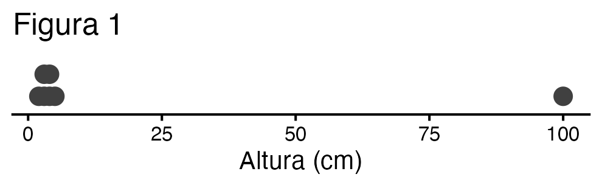

¿Cuál afirmación es correcta?

A. La media y la mediana son iguales  
B. La mediana es mayor que la media  
C. La media es mayor que la mediana  
D. La moda es mayor que la media

### 22.

En una parcela se contó el número de frutos de cinco plantas. La Figura 2 presenta el resultado.

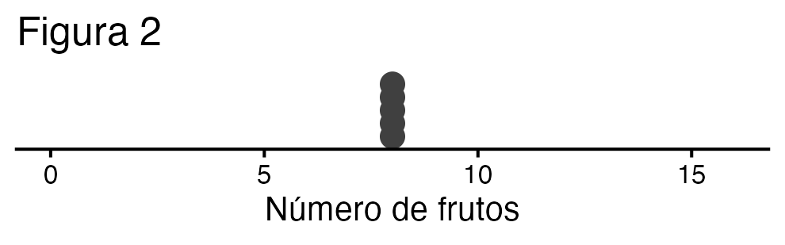

Para estos datos:

A. El rango es 8 y la varianza es 8  
B. El rango es 1 y la varianza es 0  
C. El rango es 0 y la varianza no puede calcularse  
D. El rango es 0 y la varianza es 0

### 23.

La altura de varias plantas se midió en centímetros. Las unidades de la varianza y de la desviación estándar son, respectivamente:

A. cm y cm  
B. cm y cm al cuadrado  
C. cm al cuadrado y cm  
D. Ninguna de las dos tiene unidades

### 24.

La Figura 3 presenta nueve observaciones y su diagrama de caja.

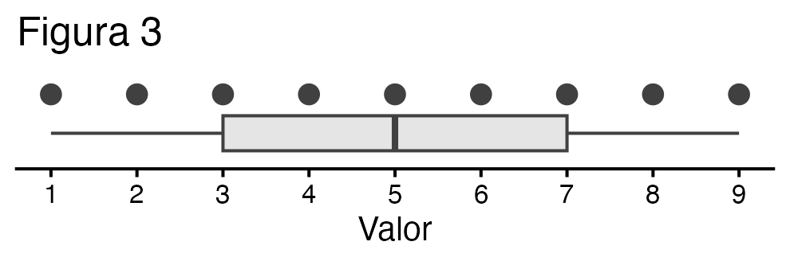

En esta figura, los valores de Q25, Q50 y Q75 son, respectivamente:

A. 1, 5 y 9  
B. 3, 5 y 7  
C. 3, 4 y 7  
D. 2, 5 y 8

### 25.

Las Figuras 4, 5 y 6 presentan tres distribuciones de frecuencia. Las preguntas 25, 26 y 27 se refieren a ellas.

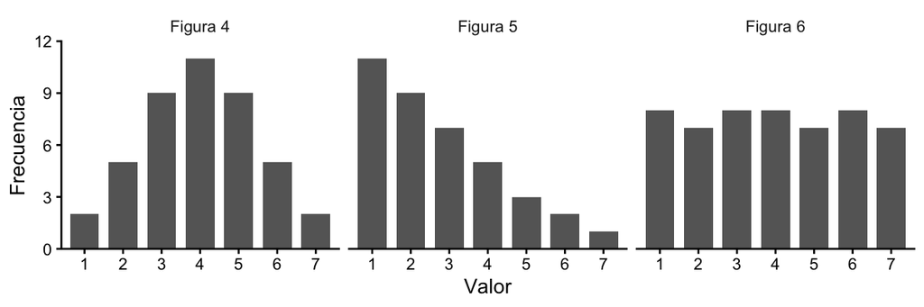

Observe la Figura 4.

La distribución es:

A. Aproximadamente simétrica  
B. Sesgada a la derecha  
C. Sesgada a la izquierda  
D. Uniforme

### 26.

Observe la Figura 5.

La distribución es:

A. Simétrica  
B. Bimodal  
C. Sesgada a la izquierda  
D. Sesgada a la derecha

### 27.

Observe la Figura 6.

La distribución es:

A. Aproximadamente uniforme  
B. Bimodal  
C. Sesgada a la derecha  
D. Sesgada a la izquierda

### 28.

Observe la Figura 7.

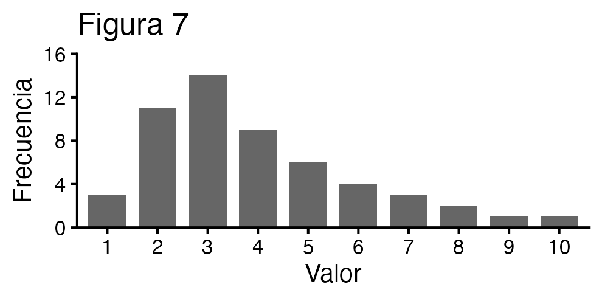

En una distribución como esta se espera que:

A. La media sea mayor que la mediana y la oblicuidad sea positiva  
B. La media sea menor que la mediana y la oblicuidad sea negativa  
C. La media y la mediana sean iguales y la oblicuidad sea cero  
D. La moda sea mayor que la media

### 29.

Se midió el largo de la hoja en 40 individuos de una población de *Lepanthes eltoroensis* que contiene miles de individuos. El promedio de esos 40 individuos es:

A. Un parámetro, simbolizado con la letra griega $\mu$  
B. Un parámetro, simbolizado con $\bar{x}$  
C. Un estadístico, simbolizado con la letra griega $\sigma$  
D. Un estadístico, simbolizado con $\bar{x}$

### 30.

Una balanza pesó cinco veces la misma muestra. La Figura 8 presenta las cinco lecturas y el peso verdadero de la muestra.

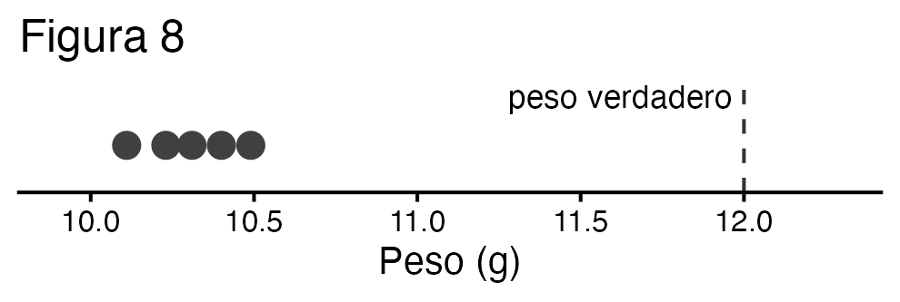

La balanza es:

A. Exacta y precisa  
B. Exacta pero no precisa  
C. Precisa pero no exacta  
D. Ni exacta ni precisa

### 31.

La siguiente tabla resume el número de frutos producidos por planta.

| Clase | Frecuencia |
| --- | --- |
| 0 a 9 | 5 |
| 10 a 19 | 15 |
| 20 a 29 | 20 |
| 30 a 39 | 10 |

¿Qué porcentaje de las plantas produjo menos de 20 frutos?

A. 20%  
B. 30%  
C. 40%  
D. 60%

### 32.

Un investigador quiere saber si dos poblaciones de orquídeas difieren en el largo promedio de la hoja. La hipótesis nula apropiada es:

A. El largo promedio de la hoja es igual en las dos poblaciones  
B. Las dos poblaciones difieren en el largo promedio de la hoja  
C. La población con la muestra más grande tiene hojas más largas  
D. El largo de la hoja depende de la elevación

### 33.

Un investigador concluye que existe una diferencia entre dos poblaciones, pero en realidad las dos poblaciones no difieren. Este investigador cometió:

A. Un error de muestreo  
B. Un error de tipo I  
C. Un error de tipo II  
D. Un error de medición

### 34.

En una prueba estadística se obtuvo un valor de p de 0.03, con un alfa de 0.05. La interpretación correcta es:

A. La probabilidad de que la hipótesis nula sea cierta es 0.03  
B. La hipótesis alterna tiene 97% de probabilidad de ser cierta  
C. El 3% de las observaciones son diferentes del resto  
D. El resultado observado, o uno más extremo, tiene probabilidad 0.03 si la hipótesis nula es cierta

### 35.

La Figura 9 presenta la distribución de 30 observaciones.

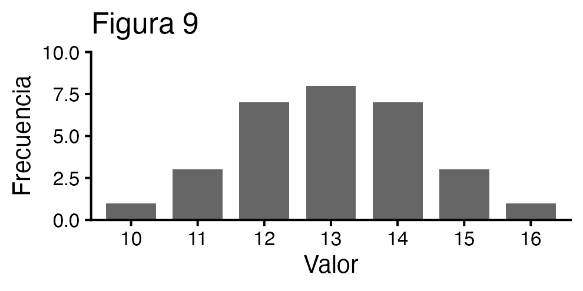

A cada una de esas 30 observaciones se le suma 5. Comparado con los datos originales:

A. La media aumenta en 5 y la desviación estándar no cambia  
B. La media aumenta en 5 y la desviación estándar aumenta en 5  
C. La media no cambia y la desviación estándar aumenta en 5  
D. Ni la media ni la desviación estándar cambian

### 36.

Se estudia la misma población con dos muestras, una de 25 individuos y otra de 100 individuos. Comparada con la muestra de 25, en la muestra de 100 se espera que:

A. La desviación estándar sea aproximadamente la mitad y el error estándar no cambie  
B. La desviación estándar y el error estándar se reduzcan ambos a la mitad  
C. La desviación estándar sea aproximadamente la misma y el error estándar sea aproximadamente la mitad  
D. Ambos aumenten, porque hay más observaciones

### 37.

La Figura 10 presenta el largo de la hoja de las 40 plantas de una muestra, junto al intervalo de confianza de 95% del promedio, que va de 4.2 a 5.8 cm.

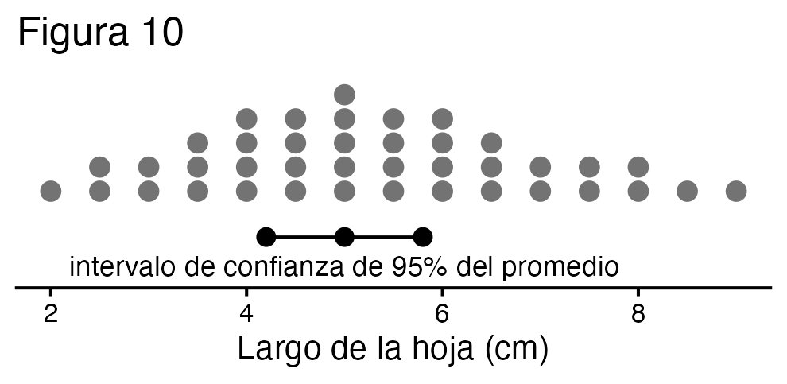

La interpretación correcta del intervalo es:

A. El 95% de las hojas de la muestra miden entre 4.2 y 5.8 cm  
B. El 95% de las hojas de la población miden entre 4.2 y 5.8 cm  
C. La probabilidad de que una hoja escogida al azar mida entre 4.2 y 5.8 cm es 0.95  
D. Si el muestreo se repitiera muchas veces, cerca del 95% de los intervalos construidos de esa manera contendrían el promedio verdadero de la población

### 38.

Los dos conjuntos de datos de la Figura 11 tienen la misma media, 5, y el mismo rango, 8.

Conjunto A: $1,\ 5,\ 5,\ 5,\ 9$

Conjunto B: $1,\ 1,\ 5,\ 9,\ 9$

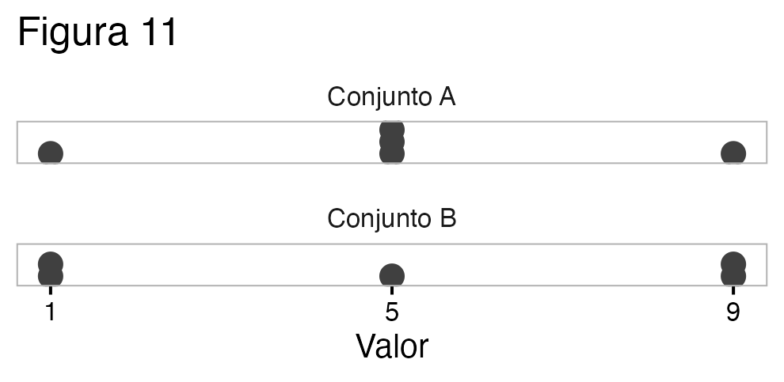

¿Cuál afirmación es correcta?

A. Tienen la misma varianza, porque la media y el rango son iguales  
B. El Conjunto A tiene mayor varianza  
C. El Conjunto B tiene mayor varianza  
D. No se puede comparar la varianza sin calcularla

### 39. (2 puntos)

Un compañero le dice: “calculé la media de mis datos y salió 45 cm, así que la mayoría de mis plantas mide cerca de 45 cm”. Explique en dos o tres oraciones por qué esa conclusión puede ser incorrecta, y mencione qué índice adicional pediría Ud. para evaluarla.

### 40. (2 puntos)

Los dos conjuntos de datos de la Figura 12 tienen media igual a 10.

Conjunto A: $9,\ 10,\ 10,\ 10,\ 11$

Conjunto B: $2,\ 5,\ 10,\ 15,\ 18$

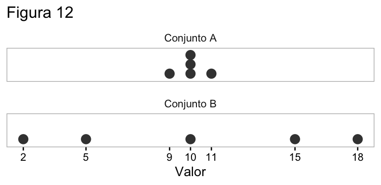

¿Cuál conjunto tiene mayor desviación estándar? Justifique su respuesta sin calcularla.